# Lab 8

## Model the relationship with home prive as DV

Saturated model

```r
homes_lm1 <- lm(Price ~ City + Bedrooms + Bathrooms + SqFt + PricePerSqFt + Status, data = homes_sub)
# looking at this data set- PricePerSquareFt is going to be redundant of price and SqFt. Other examples might be if there's going to be an obvious correlation between bathrooms and bedrooms

# Make a subset that only contains the quantative valiables

homes_quant <- homes_sub %>%
  select(Price: PricePerSqFt)
homes_cor <- cor(homes_quant)
homes_cor
```

```
##                  Price    Bedrooms Bathrooms      SqFt PricePerSqFt
## Price        1.0000000  0.27035797 0.4867782 0.6372218   0.75236213
## Bedrooms     0.2703580  1.00000000 0.6429855 0.6195391  -0.04047523
## Bathrooms    0.4867782  0.64298545 1.0000000 0.7721538   0.11223286
## SqFt         0.6372218  0.61953907 0.7721538 1.0000000   0.17961762
## PricePerSqFt 0.7523621 -0.04047523 0.1122329 0.1796176   1.00000000
```

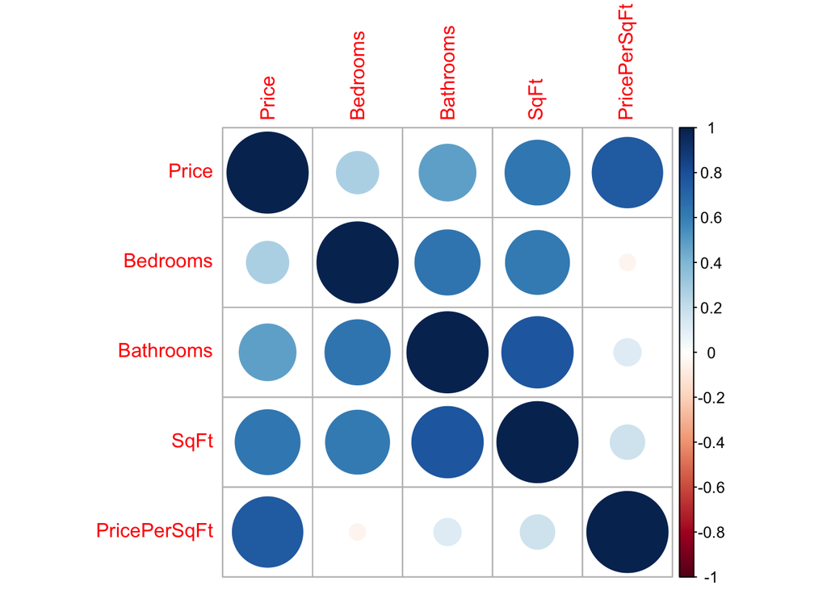

```r
## If i want to make a corrlation plot I can do:
corrplot(homes_cor)
```

```r
homes_lm1
```

```
##
## Call:
## lm(formula = Price ~ City + Bedrooms + Bathrooms + SqFt + PricePerSqFt +
##     Status, data = homes_sub)
##
## Coefficients:
##            (Intercept)          CityAtascadero     CitySan Luis Obispo
##              -626690.9                 -9068.2                -76863.0
## CitySanta Maria-Orcutt                Bedrooms               Bathrooms
##               120160.7                -30792.8                 27998.7
##                   SqFt            PricePerSqFt           StatusRegular
##                  230.7                  2962.8                -19792.3
##       StatusShort Sale
##               -41575.7
```

# The way we interpret values in homes_lm1- if everything else is the same, I would expect a home in Atascadero to cost $9,068 less than a house in Arroyo Grande

# How would I explore the diagnositic plots?

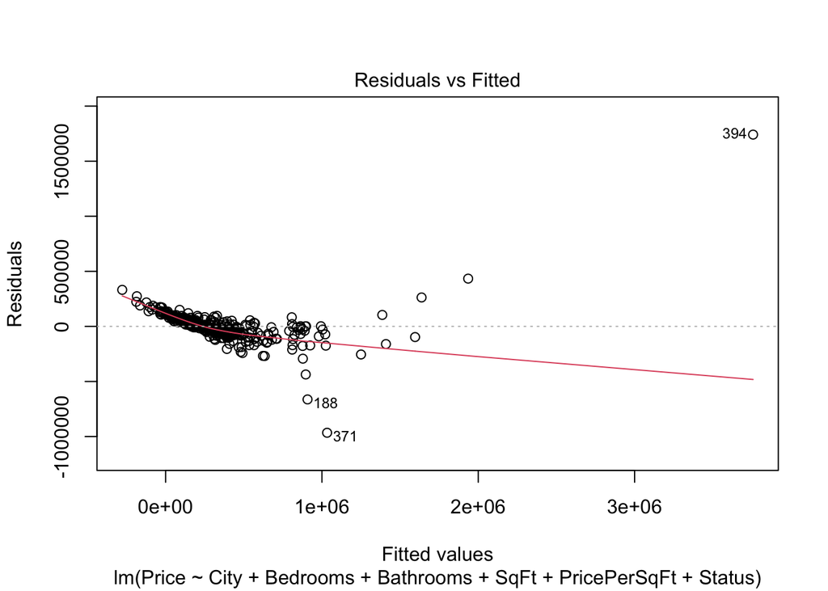

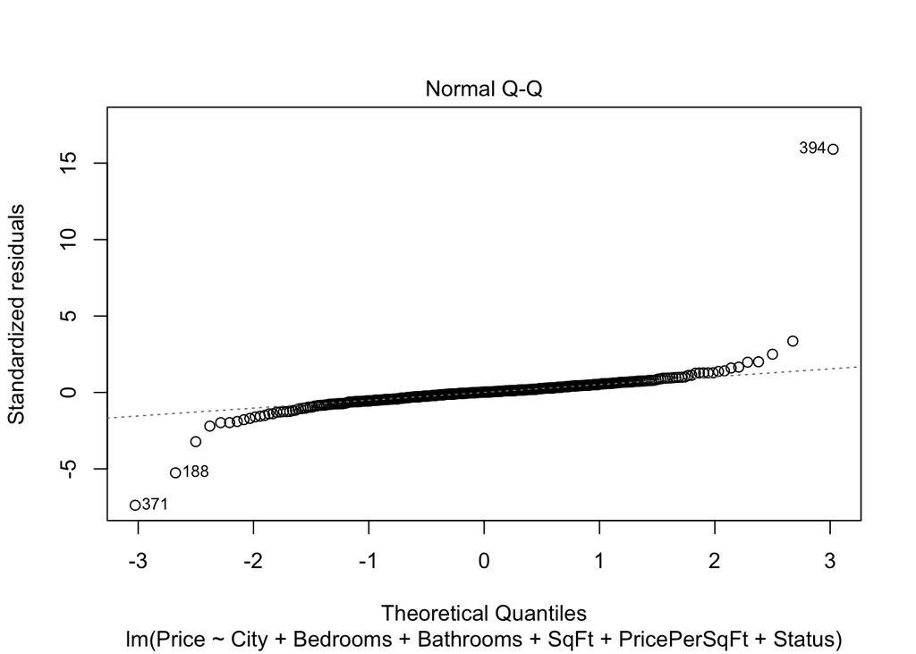

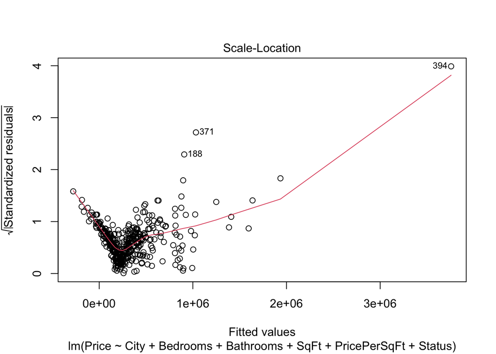

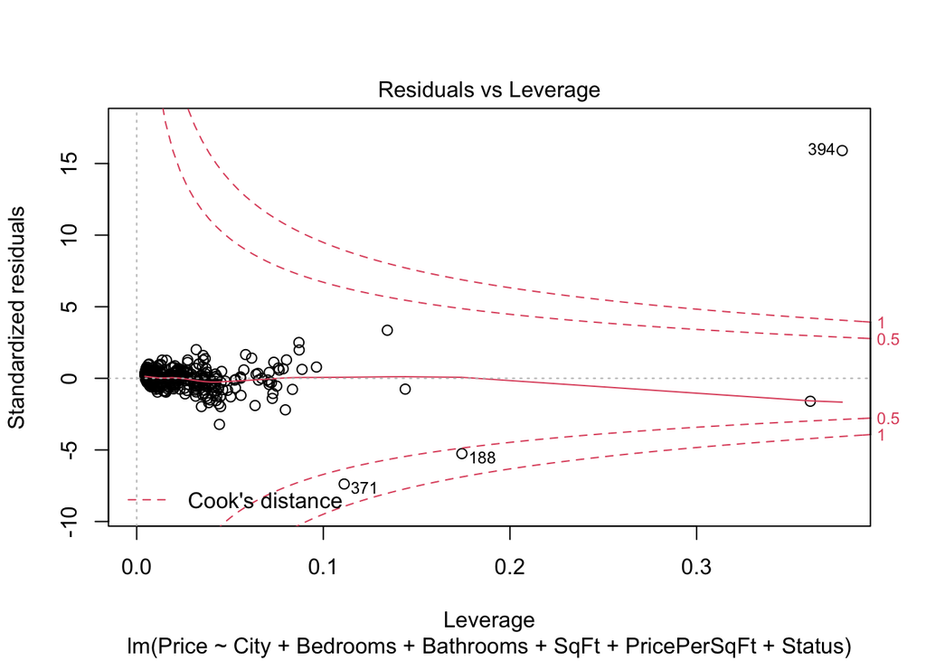

```r
plot(homes_lm1)
```

# Lets try another model

Try another model where we simplfy this a bit: Only include variables for - City - SqFt - Status

```r
homes_lm2 <- lm(Price ~ City + SqFt + Status, data = homes_sub)
homes_lm2 #call this to view
```

```
##
## Call:
## lm(formula = Price ~ City + SqFt + Status, data = homes_sub)
##
## Coefficients:
##            (Intercept)          CityAtascadero     CitySan Luis Obispo
##               106333.1               -202157.5                 34525.4
## CitySanta Maria-Orcutt                    SqFt           StatusRegular
##              -275841.3                   245.9                209998.9
##       StatusShort Sale
##                 2282.4
```

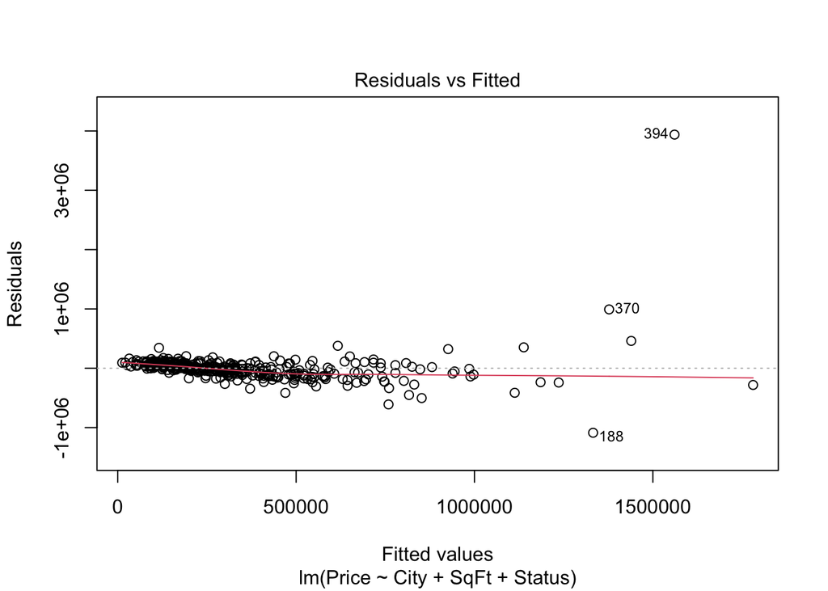

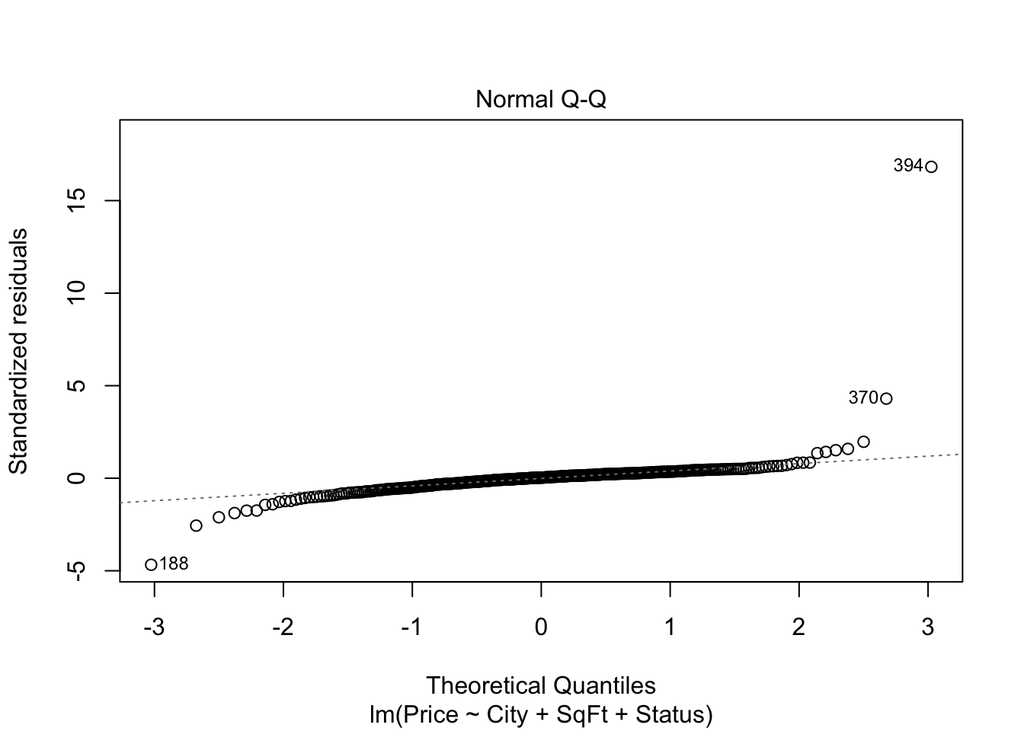

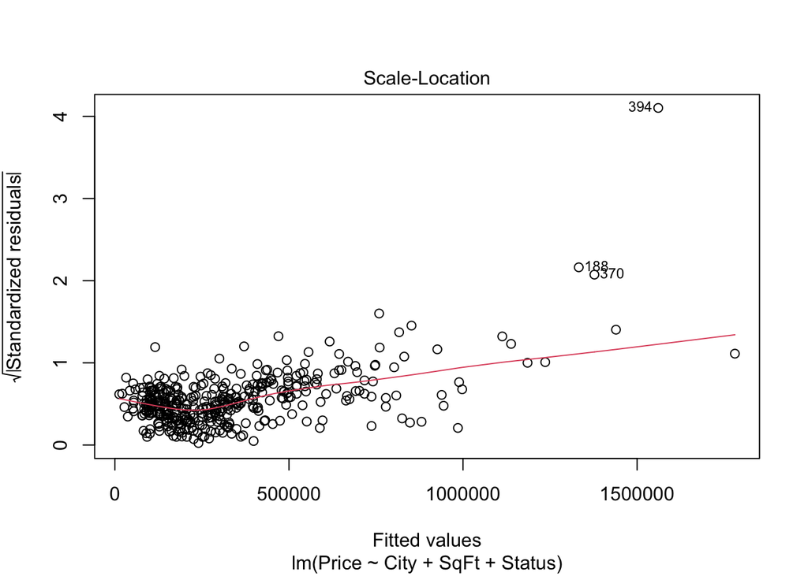

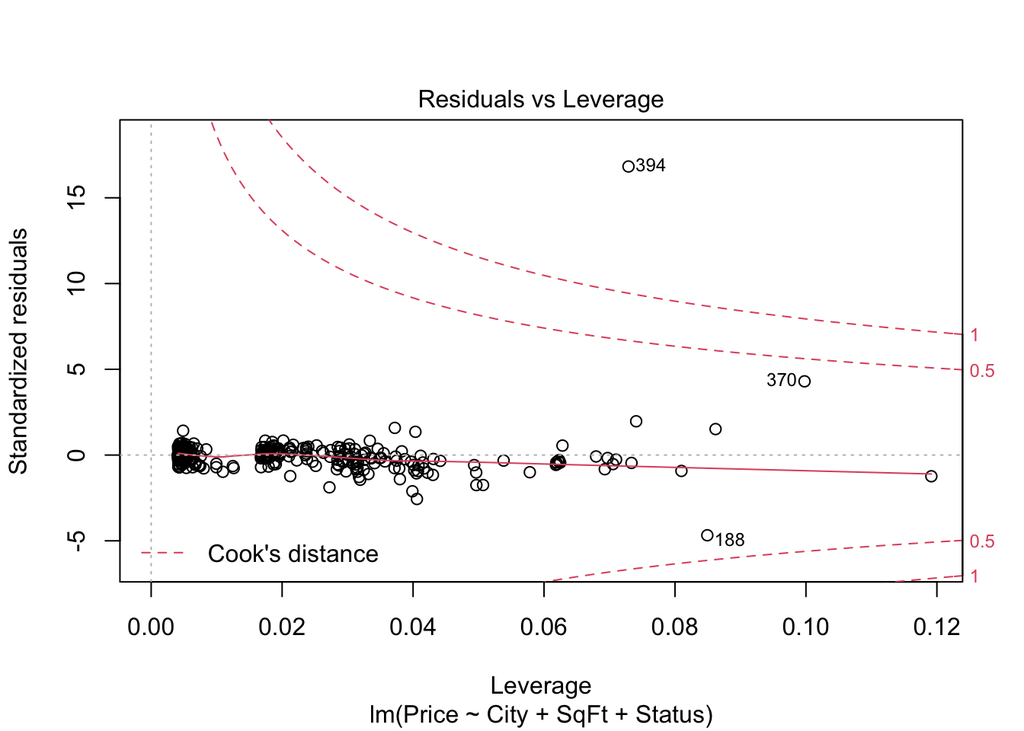

```r
plot(homes_lm2)
```

Let’s talk about model fit- look at summary(homes_lm1) we get 0.84 for R^2- this means that 84% of the variance in home price is explained by the variable predictors in this model That still means there’s 16% of variables that explain variance that we don’t have p-value: < 2.2e-16

Let’s look at our second model summary(homes_lm2) This model only describes 52.68% of variance

Now we find the AIC value of each model

```r
AIC(homes_lm1)
```

```
## [1] 10699.25
```

```r
AIC(homes_lm2)
```

```
## [1] 11148
```

```r
# A lower AIC values indicated a better balance between model fit and model complexity
# Looking at our numbers- the first one is a better option, but we still have some read flags about using this one. So maybe we need to find an intermediate model that includes some different variables
```

### so let’s try another premuatation of this model that you think might make sense, check out and compare the model fit, outputs and AIC value

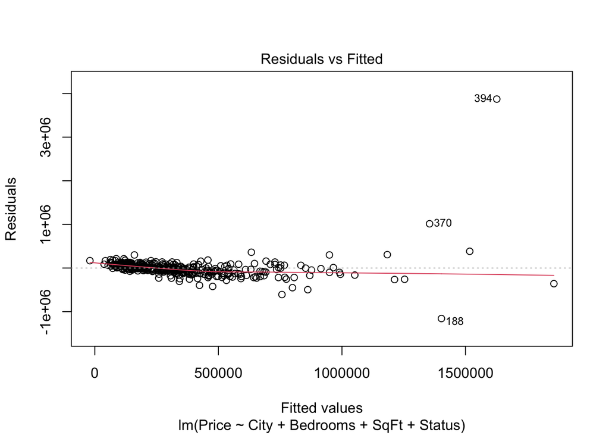

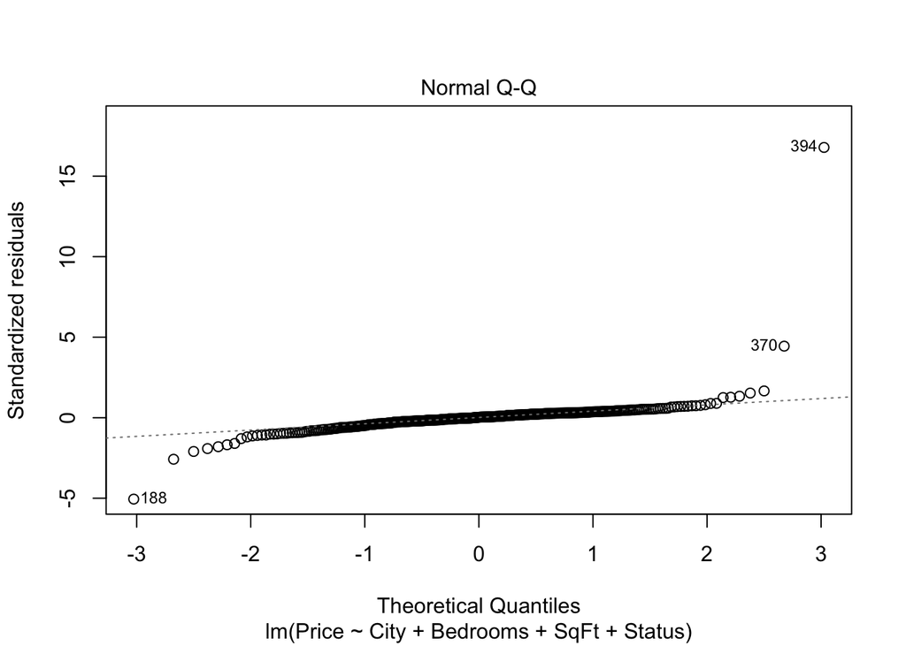

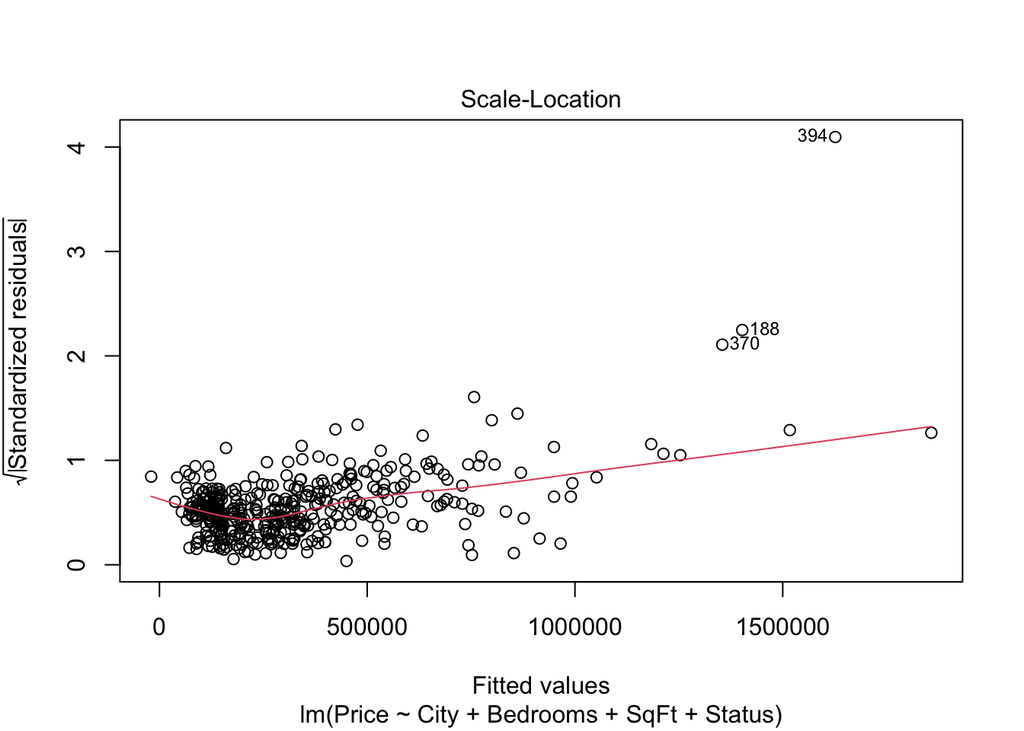

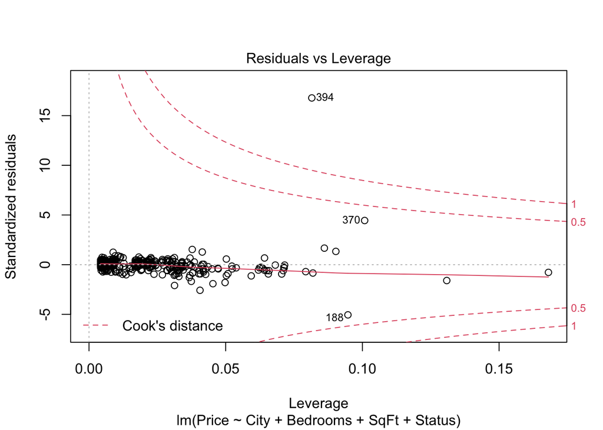

```r
homes_lm3 <- lm(Price ~ City + Bedrooms + SqFt + Status, data = homes_sub)
plot(homes_lm3)
```

```r
homes_lm3
```

```
##
## Call:
## lm(formula = Price ~ City + Bedrooms + SqFt + Status, data = homes_sub)
##
## Coefficients:
##            (Intercept)          CityAtascadero     CitySan Luis Obispo
##               195411.3               -192720.3                 30329.4
## CitySanta Maria-Orcutt                Bedrooms                    SqFt
##              -256745.2                -51934.4                   282.6
##          StatusRegular        StatusShort Sale
##               208959.7                   373.0
```

```r
summary(homes_lm3)
```

```
##
## Call:
## lm(formula = Price ~ City + Bedrooms + SqFt + Status, data = homes_sub)
##
## Residuals:
##      Min       1Q   Median       3Q      Max
## -1157575   -59536     6015    66999  3872483
##
## Coefficients:
##                          Estimate Std. Error t value Pr(>|t|)
## (Intercept)             195411.31   64547.65   3.027  0.00263 **
## CityAtascadero         -192720.33   48713.65  -3.956 9.03e-05 ***
## CitySan Luis Obispo      30329.41   70175.70   0.432  0.66584
## CitySanta Maria-Orcutt -256745.21   43072.76  -5.961 5.57e-09 ***
## Bedrooms                -51934.39   17631.90  -2.945  0.00342 **
## SqFt                       282.59      19.63  14.397  < 2e-16 ***
## StatusRegular           208959.75   49164.06   4.250 2.67e-05 ***
## StatusShort Sale           372.99   32586.28   0.011  0.99087
## ---
## Signif. codes:  0 '***' 0.001 '**' 0.01 '*' 0.05 '.' 0.1 ' ' 1
##
## Residual standard error: 240800 on 395 degrees of freedom
## Multiple R-squared:  0.5439, Adjusted R-squared:  0.5358
## F-statistic:  67.3 on 7 and 395 DF,  p-value: < 2.2e-16
```

```r
AIC(homes_lm3)
```

```
## [1] 11141.24
```

So this can help us think about how variables are related but none of them make a great model

use `modelsummary` to show model outputs side-by-side: Heads up - if you use modelsummary to return outputs of multiple models, it wants you to feed it as a list

```r
modelsummary(list(homes_lm1, homes_lm2, homes_lm3))
```

|  | Model 1 | Model 2 | Model 3 |
| --- | --- | --- | --- |
| (Intercept) | −626690.877 | 106333.118 | 195411.312 |
|  | (47272.695) | (57574.568) | (64547.654) |
| CityAtascadero | −9068.194 | −202157.509 | −192720.329 |
|  | (29012.351) | (49077.007) | (48713.650) |
| CitySan Luis Obispo | −76863.041 | 34525.409 | 30329.412 |
|  | (41030.471) | (70837.962) | (70175.703) |
| CitySanta Maria-Orcutt | 120160.701 | −275841.282 | −256745.209 |
|  | (28338.220) | (42992.765) | (43072.762) |
| Bedrooms | −30792.773 |  | −51934.394 |
|  | (10841.581) |  | (17631.905) |
| Bathrooms | 27998.673 |  |  |
|  | (13251.722) |  |  |
| SqFt | 230.726 | 245.934 | 282.586 |
|  | (14.308) | (15.325) | (19.627) |
| PricePerSqFt | 2962.850 |  |  |
|  | (105.537) |  |  |
| StatusRegular | −19792.272 | 209998.857 | 208959.747 |
|  | (29484.606) | (49636.975) | (49164.056) |
| StatusShort Sale | −41575.706 | 2282.420 | 372.987 |
|  | (18900.819) | (32894.066) | (32586.276) |
| Num.Obs. | 403 | 403 | 403 |
| R2 | 0.849 | 0.534 | 0.544 |
| R2 Adj. | 0.846 | 0.527 | 0.536 |
| AIC | 10699.2 | 11148.0 | 11141.2 |
| BIC | 10743.2 | 11180.0 | 11177.2 |
| Log.Lik. | −5338.624 | −5566.000 | −5561.622 |
| F | 245.896 | 75.603 | 67.298 |